# Risk Factor Analysis

## Outcome Variable

**Outcome Variable:** dead0plus

## Predictor Variables

**Intervention Variable:** ever_sstunted024

**Adjustment Set:**

- sex
- arm
- brthmon
- vagbrth
- hhwealth_quart
- W_mage
- W_mhtcm
- W_mwtkg
- W_mbmi
- W_meducyrs
- W_feducyrs
- W_nrooms
- W_parity
- impsan
- safeh20
- delta_vagbrth
- delta_hhwealth_quart
- delta_W_mage
- delta_W_mhtcm
- delta_W_mwtkg
- delta_W_mbmi
- delta_W_meducyrs
- delta_W_feducyrs
- delta_W_nrooms
- delta_W_parity
- delta_impsan
- delta_safeh20

## Stratifying Variables

The analysis was stratified on these variable(s):

- studyid
- country

## Data Summary

| studyid | country | ever_sstunted024 | dead0plus | n_cell | n | outcome_variable |
| --- | --- | --- | --- | --- | --- | --- |
| ki0047075b-MAL-ED | BANGLADESH | 0 | 0 | 205 | 265 | dead0plus |
| ki0047075b-MAL-ED | BANGLADESH | 0 | 1 | 2 | 265 | dead0plus |
| ki0047075b-MAL-ED | BANGLADESH | 1 | 0 | 57 | 265 | dead0plus |
| ki0047075b-MAL-ED | BANGLADESH | 1 | 1 | 1 | 265 | dead0plus |
| ki0047075b-MAL-ED | INDIA | 0 | 0 | 190 | 251 | dead0plus |
| ki0047075b-MAL-ED | INDIA | 0 | 1 | 2 | 251 | dead0plus |
| ki0047075b-MAL-ED | INDIA | 1 | 0 | 59 | 251 | dead0plus |
| ki0047075b-MAL-ED | INDIA | 1 | 1 | 0 | 251 | dead0plus |
| ki0047075b-MAL-ED | PERU | 0 | 0 | 237 | 303 | dead0plus |
| ki0047075b-MAL-ED | PERU | 0 | 1 | 2 | 303 | dead0plus |
| ki0047075b-MAL-ED | PERU | 1 | 0 | 64 | 303 | dead0plus |
| ki0047075b-MAL-ED | PERU | 1 | 1 | 0 | 303 | dead0plus |
| ki0047075b-MAL-ED | SOUTH AFRICA | 0 | 0 | 241 | 314 | dead0plus |
| ki0047075b-MAL-ED | SOUTH AFRICA | 0 | 1 | 0 | 314 | dead0plus |
| ki0047075b-MAL-ED | SOUTH AFRICA | 1 | 0 | 72 | 314 | dead0plus |
| ki0047075b-MAL-ED | SOUTH AFRICA | 1 | 1 | 1 | 314 | dead0plus |
| ki0047075b-MAL-ED | TANZANIA, UNITED REPUBLIC OF | 0 | 0 | 123 | 262 | dead0plus |
| ki0047075b-MAL-ED | TANZANIA, UNITED REPUBLIC OF | 0 | 1 | 2 | 262 | dead0plus |
| ki0047075b-MAL-ED | TANZANIA, UNITED REPUBLIC OF | 1 | 0 | 136 | 262 | dead0plus |
| ki0047075b-MAL-ED | TANZANIA, UNITED REPUBLIC OF | 1 | 1 | 1 | 262 | dead0plus |
| ki1000109-EE | PAKISTAN | 0 | 0 | 151 | 379 | dead0plus |
| ki1000109-EE | PAKISTAN | 0 | 1 | 0 | 379 | dead0plus |
| ki1000109-EE | PAKISTAN | 1 | 0 | 224 | 379 | dead0plus |
| ki1000109-EE | PAKISTAN | 1 | 1 | 4 | 379 | dead0plus |
| ki1000304-VITAMIN-A | INDIA | 0 | 0 | 2897 | 3907 | dead0plus |
| ki1000304-VITAMIN-A | INDIA | 0 | 1 | 49 | 3907 | dead0plus |
| ki1000304-VITAMIN-A | INDIA | 1 | 0 | 933 | 3907 | dead0plus |
| ki1000304-VITAMIN-A | INDIA | 1 | 1 | 28 | 3907 | dead0plus |
| ki1000304b-SAS-CompFeed | INDIA | 0 | 0 | 999 | 1533 | dead0plus |
| ki1000304b-SAS-CompFeed | INDIA | 0 | 1 | 27 | 1533 | dead0plus |
| ki1000304b-SAS-CompFeed | INDIA | 1 | 0 | 484 | 1533 | dead0plus |
| ki1000304b-SAS-CompFeed | INDIA | 1 | 1 | 23 | 1533 | dead0plus |
| ki1000304b-SAS-FoodSuppl | INDIA | 0 | 0 | 215 | 418 | dead0plus |
| ki1000304b-SAS-FoodSuppl | INDIA | 0 | 1 | 2 | 418 | dead0plus |
| ki1000304b-SAS-FoodSuppl | INDIA | 1 | 0 | 197 | 418 | dead0plus |
| ki1000304b-SAS-FoodSuppl | INDIA | 1 | 1 | 4 | 418 | dead0plus |
| ki1017093b-PROVIDE | BANGLADESH | 0 | 0 | 601 | 700 | dead0plus |
| ki1017093b-PROVIDE | BANGLADESH | 0 | 1 | 4 | 700 | dead0plus |
| ki1017093b-PROVIDE | BANGLADESH | 1 | 0 | 94 | 700 | dead0plus |
| ki1017093b-PROVIDE | BANGLADESH | 1 | 1 | 1 | 700 | dead0plus |
| ki1066203-TanzaniaChild2 | TANZANIA, UNITED REPUBLIC OF | 0 | 0 | 2156 | 2396 | dead0plus |
| ki1066203-TanzaniaChild2 | TANZANIA, UNITED REPUBLIC OF | 0 | 1 | 1 | 2396 | dead0plus |
| ki1066203-TanzaniaChild2 | TANZANIA, UNITED REPUBLIC OF | 1 | 0 | 239 | 2396 | dead0plus |
| ki1066203-TanzaniaChild2 | TANZANIA, UNITED REPUBLIC OF | 1 | 1 | 0 | 2396 | dead0plus |
| ki1101329-Keneba | GAMBIA | 0 | 0 | 2233 | 2915 | dead0plus |
| ki1101329-Keneba | GAMBIA | 0 | 1 | 63 | 2915 | dead0plus |
| ki1101329-Keneba | GAMBIA | 1 | 0 | 583 | 2915 | dead0plus |
| ki1101329-Keneba | GAMBIA | 1 | 1 | 36 | 2915 | dead0plus |
| ki1112895-Burkina Faso Zn | BURKINA FASO | 0 | 0 | 6264 | 7164 | dead0plus |
| ki1112895-Burkina Faso Zn | BURKINA FASO | 0 | 1 | 37 | 7164 | dead0plus |
| ki1112895-Burkina Faso Zn | BURKINA FASO | 1 | 0 | 852 | 7164 | dead0plus |
| ki1112895-Burkina Faso Zn | BURKINA FASO | 1 | 1 | 11 | 7164 | dead0plus |
| ki1113344-GMS-Nepal | NEPAL | 0 | 0 | 525 | 698 | dead0plus |
| ki1113344-GMS-Nepal | NEPAL | 0 | 1 | 4 | 698 | dead0plus |
| ki1113344-GMS-Nepal | NEPAL | 1 | 0 | 165 | 698 | dead0plus |
| ki1113344-GMS-Nepal | NEPAL | 1 | 1 | 4 | 698 | dead0plus |
| ki1126311-ZVITAMBO | ZIMBABWE | 0 | 0 | 10885 | 14074 | dead0plus |
| ki1126311-ZVITAMBO | ZIMBABWE | 0 | 1 | 823 | 14074 | dead0plus |
| ki1126311-ZVITAMBO | ZIMBABWE | 1 | 0 | 2073 | 14074 | dead0plus |
| ki1126311-ZVITAMBO | ZIMBABWE | 1 | 1 | 293 | 14074 | dead0plus |
| ki1148112-iLiNS-DOSE | MALAWI | 0 | 0 | 1487 | 1931 | dead0plus |
| ki1148112-iLiNS-DOSE | MALAWI | 0 | 1 | 102 | 1931 | dead0plus |
| ki1148112-iLiNS-DOSE | MALAWI | 1 | 0 | 316 | 1931 | dead0plus |
| ki1148112-iLiNS-DOSE | MALAWI | 1 | 1 | 26 | 1931 | dead0plus |
| ki1148112-iLiNS-DYAD-M | MALAWI | 0 | 0 | 971 | 1204 | dead0plus |
| ki1148112-iLiNS-DYAD-M | MALAWI | 0 | 1 | 33 | 1204 | dead0plus |
| ki1148112-iLiNS-DYAD-M | MALAWI | 1 | 0 | 190 | 1204 | dead0plus |
| ki1148112-iLiNS-DYAD-M | MALAWI | 1 | 1 | 10 | 1204 | dead0plus |
| kiGH5241-JiVitA-3 | BANGLADESH | 0 | 0 | 21747 | 27227 | dead0plus |
| kiGH5241-JiVitA-3 | BANGLADESH | 0 | 1 | 458 | 27227 | dead0plus |
| kiGH5241-JiVitA-3 | BANGLADESH | 1 | 0 | 4637 | 27227 | dead0plus |
| kiGH5241-JiVitA-3 | BANGLADESH | 1 | 1 | 385 | 27227 | dead0plus |
| kiGH5241-JiVitA-4 | BANGLADESH | 0 | 0 | 4305 | 5442 | dead0plus |
| kiGH5241-JiVitA-4 | BANGLADESH | 0 | 1 | 31 | 5442 | dead0plus |
| kiGH5241-JiVitA-4 | BANGLADESH | 1 | 0 | 1087 | 5442 | dead0plus |
| kiGH5241-JiVitA-4 | BANGLADESH | 1 | 1 | 19 | 5442 | dead0plus |

The following strata were considered:

- studyid: ki0047075b-MAL-ED, country: BANGLADESH
- studyid: ki0047075b-MAL-ED, country: INDIA
- studyid: ki0047075b-MAL-ED, country: PERU
- studyid: ki0047075b-MAL-ED, country: SOUTH AFRICA
- studyid: ki0047075b-MAL-ED, country: TANZANIA, UNITED REPUBLIC OF
- studyid: ki1000109-EE, country: PAKISTAN
- studyid: ki1000304-VITAMIN-A, country: INDIA
- studyid: ki1000304b-SAS-CompFeed, country: INDIA
- studyid: ki1000304b-SAS-FoodSuppl, country: INDIA
- studyid: ki1017093b-PROVIDE, country: BANGLADESH
- studyid: ki1066203-TanzaniaChild2, country: TANZANIA, UNITED REPUBLIC OF
- studyid: ki1101329-Keneba, country: GAMBIA
- studyid: ki1112895-Burkina Faso Zn, country: BURKINA FASO
- studyid: ki1113344-GMS-Nepal, country: NEPAL
- studyid: ki1126311-ZVITAMBO, country: ZIMBABWE
- studyid: ki1148112-iLiNS-DOSE, country: MALAWI
- studyid: ki1148112-iLiNS-DYAD-M, country: MALAWI
- studyid: kiGH5241-JiVitA-3, country: BANGLADESH
- studyid: kiGH5241-JiVitA-4, country: BANGLADESH

### Dropped Strata

Some strata were dropped due to rare outcomes:

- studyid: ki0047075b-MAL-ED, country: BANGLADESH
- studyid: ki0047075b-MAL-ED, country: INDIA
- studyid: ki0047075b-MAL-ED, country: PERU
- studyid: ki0047075b-MAL-ED, country: SOUTH AFRICA
- studyid: ki0047075b-MAL-ED, country: TANZANIA, UNITED REPUBLIC OF
- studyid: ki1000109-EE, country: PAKISTAN
- studyid: ki1000304b-SAS-FoodSuppl, country: INDIA
- studyid: ki1017093b-PROVIDE, country: BANGLADESH
- studyid: ki1066203-TanzaniaChild2, country: TANZANIA, UNITED REPUBLIC OF
- studyid: ki1113344-GMS-Nepal, country: NEPAL

## Methods Detail

We’re interested in the causal parameters $E[Y_a]$ for all values of $a \in \mathcal{A}$. These parameters represent the mean outcome if, possibly contrary to fact, we intervened to set all units to have $A=a$. Under the randomization and positivity assumptions, these are identified by the statistical parameters $\psi_a=E_W[E_{Y|A,W}(Y|A=a,W)]$. In addition, we’re interested in the mean of $Y$, $E[Y]$ under no intervention (the observed mean). We will estimate these parameters by using SuperLearner to fit the relevant likelihood factors – $E_{Y|A,W}(Y|A=a,W)$ and $p(A=a|W)$, and then updating our likelihood fit using a joint TMLE.

For unadjusted analyses ($W=\{\}$), initial likelihoods were estimated using Lrnr_glm to estimate the simple $E(Y|A)$ and Lrnr_mean to estimate $p(A)$. For adjusted analyses, a small library containing Lrnr_glmnet, Lrnr_xgboost, and Lrnr_mean was used.

Having estimated these parameters, we will then use the delta method to estimate relative risks and attributable risks relative to a prespecified baseline level of $A$.

# Results Detail

## Results Plots

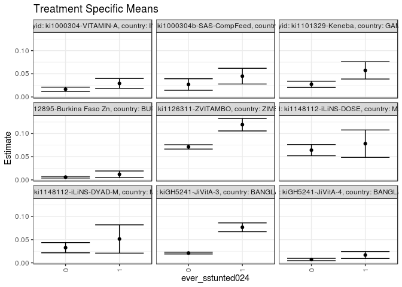

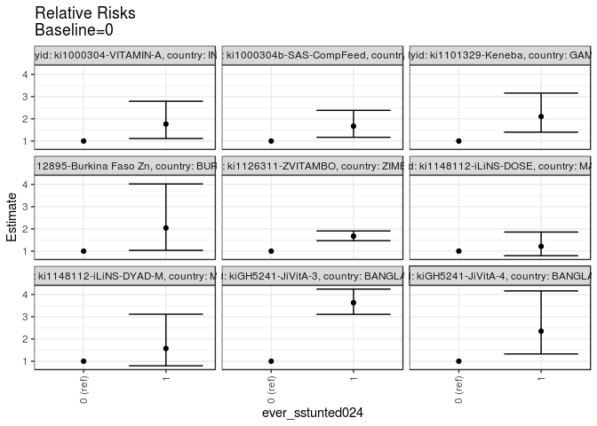

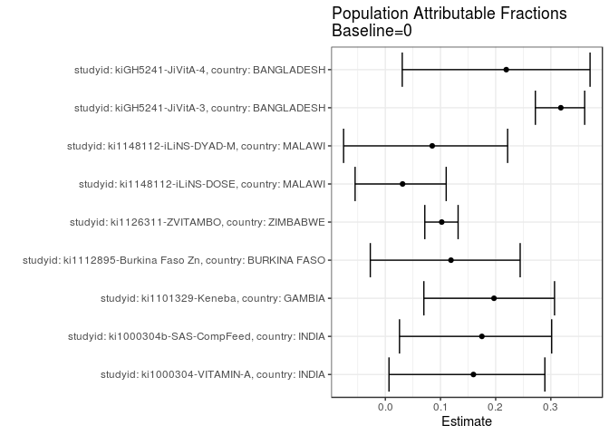

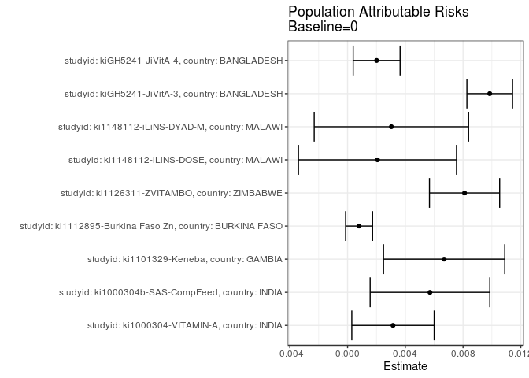

## Results Table

### Parameter: TSM

| studyid | country | intervention_level | baseline_level | estimate | ci_lower | ci_upper |
| --- | --- | --- | --- | --- | --- | --- |
| ki1000304-VITAMIN-A | INDIA | 0 | NA | 0.0165607 | 0.0119567 | 0.0211648 |
| ki1000304-VITAMIN-A | INDIA | 1 | NA | 0.0292038 | 0.0185379 | 0.0398697 |
| ki1000304b-SAS-CompFeed | INDIA | 0 | NA | 0.0269067 | 0.0144685 | 0.0393449 |
| ki1000304b-SAS-CompFeed | INDIA | 1 | NA | 0.0448952 | 0.0279112 | 0.0618792 |
| ki1101329-Keneba | GAMBIA | 0 | NA | 0.0272731 | 0.0206124 | 0.0339339 |
| ki1101329-Keneba | GAMBIA | 1 | NA | 0.0573141 | 0.0386976 | 0.0759305 |
| ki1112895-Burkina Faso Zn | BURKINA FASO | 0 | NA | 0.0059029 | 0.0040070 | 0.0077989 |
| ki1112895-Burkina Faso Zn | BURKINA FASO | 1 | NA | 0.0120547 | 0.0048618 | 0.0192477 |
| ki1126311-ZVITAMBO | ZIMBABWE | 0 | NA | 0.0711895 | 0.0665055 | 0.0758734 |
| ki1126311-ZVITAMBO | ZIMBABWE | 1 | NA | 0.1192056 | 0.1056600 | 0.1327512 |
| ki1148112-iLiNS-DOSE | MALAWI | 0 | NA | 0.0642146 | 0.0521397 | 0.0762894 |
| ki1148112-iLiNS-DOSE | MALAWI | 1 | NA | 0.0781670 | 0.0485576 | 0.1077764 |
| ki1148112-iLiNS-DYAD-M | MALAWI | 0 | NA | 0.0326787 | 0.0216581 | 0.0436992 |
| ki1148112-iLiNS-DYAD-M | MALAWI | 1 | NA | 0.0514579 | 0.0209489 | 0.0819670 |
| kiGH5241-JiVitA-3 | BANGLADESH | 0 | NA | 0.0211124 | 0.0191711 | 0.0230537 |
| kiGH5241-JiVitA-3 | BANGLADESH | 1 | NA | 0.0767062 | 0.0671986 | 0.0862139 |
| kiGH5241-JiVitA-4 | BANGLADESH | 0 | NA | 0.0071738 | 0.0045661 | 0.0097816 |
| kiGH5241-JiVitA-4 | BANGLADESH | 1 | NA | 0.0168640 | 0.0094176 | 0.0243104 |

### Parameter: E(Y)

| studyid | country | intervention_level | baseline_level | estimate | ci_lower | ci_upper |
| --- | --- | --- | --- | --- | --- | --- |
| ki1000304-VITAMIN-A | INDIA | NA | NA | 0.0197082 | 0.0153493 | 0.0240672 |
| ki1000304b-SAS-CompFeed | INDIA | NA | NA | 0.0326158 | 0.0204960 | 0.0447355 |
| ki1101329-Keneba | GAMBIA | NA | NA | 0.0339623 | 0.0273857 | 0.0405388 |
| ki1112895-Burkina Faso Zn | BURKINA FASO | NA | NA | 0.0067002 | 0.0048109 | 0.0085894 |
| ki1126311-ZVITAMBO | ZIMBABWE | NA | NA | 0.0792952 | 0.0748310 | 0.0837593 |
| ki1148112-iLiNS-DOSE | MALAWI | NA | NA | 0.0662869 | 0.0551877 | 0.0773861 |
| ki1148112-iLiNS-DYAD-M | MALAWI | NA | NA | 0.0357143 | 0.0252276 | 0.0462010 |
| kiGH5241-JiVitA-3 | BANGLADESH | NA | NA | 0.0309619 | 0.0288229 | 0.0331009 |
| kiGH5241-JiVitA-4 | BANGLADESH | NA | NA | 0.0091878 | 0.0066008 | 0.0117748 |

### Parameter: RR

| studyid | country | intervention_level | baseline_level | estimate | ci_lower | ci_upper |
| --- | --- | --- | --- | --- | --- | --- |
| ki1000304-VITAMIN-A | INDIA | 0 | 0 | 1.000000 | 1.0000000 | 1.000000 |
| ki1000304-VITAMIN-A | INDIA | 1 | 0 | 1.763437 | 1.1142768 | 2.790789 |
| ki1000304b-SAS-CompFeed | INDIA | 0 | 0 | 1.000000 | 1.0000000 | 1.000000 |
| ki1000304b-SAS-CompFeed | INDIA | 1 | 0 | 1.668551 | 1.1695299 | 2.380498 |
| ki1101329-Keneba | GAMBIA | 0 | 0 | 1.000000 | 1.0000000 | 1.000000 |
| ki1101329-Keneba | GAMBIA | 1 | 0 | 2.101483 | 1.3994346 | 3.155726 |
| ki1112895-Burkina Faso Zn | BURKINA FASO | 0 | 0 | 1.000000 | 1.0000000 | 1.000000 |
| ki1112895-Burkina Faso Zn | BURKINA FASO | 1 | 0 | 2.042153 | 1.0370474 | 4.021408 |
| ki1126311-ZVITAMBO | ZIMBABWE | 0 | 0 | 1.000000 | 1.0000000 | 1.000000 |
| ki1126311-ZVITAMBO | ZIMBABWE | 1 | 0 | 1.674483 | 1.4691479 | 1.908518 |
| ki1148112-iLiNS-DOSE | MALAWI | 0 | 0 | 1.000000 | 1.0000000 | 1.000000 |
| ki1148112-iLiNS-DOSE | MALAWI | 1 | 0 | 1.217279 | 0.7972989 | 1.858484 |
| ki1148112-iLiNS-DYAD-M | MALAWI | 0 | 0 | 1.000000 | 1.0000000 | 1.000000 |
| ki1148112-iLiNS-DYAD-M | MALAWI | 1 | 0 | 1.574665 | 0.7961745 | 3.114355 |
| kiGH5241-JiVitA-3 | BANGLADESH | 0 | 0 | 1.000000 | 1.0000000 | 1.000000 |
| kiGH5241-JiVitA-3 | BANGLADESH | 1 | 0 | 3.633230 | 3.1101237 | 4.244320 |
| kiGH5241-JiVitA-4 | BANGLADESH | 0 | 0 | 1.000000 | 1.0000000 | 1.000000 |
| kiGH5241-JiVitA-4 | BANGLADESH | 1 | 0 | 2.350779 | 1.3278154 | 4.161844 |

### Parameter: PAR

| studyid | country | intervention_level | baseline_level | estimate | ci_lower | ci_upper |
| --- | --- | --- | --- | --- | --- | --- |
| ki1000304-VITAMIN-A | INDIA | 0 | NA | 0.0031475 | 0.0002937 | 0.0060012 |
| ki1000304b-SAS-CompFeed | INDIA | 0 | NA | 0.0057091 | 0.0015636 | 0.0098545 |
| ki1101329-Keneba | GAMBIA | 0 | NA | 0.0066891 | 0.0024895 | 0.0108888 |
| ki1112895-Burkina Faso Zn | BURKINA FASO | 0 | NA | 0.0007972 | -0.0001365 | 0.0017309 |
| ki1126311-ZVITAMBO | ZIMBABWE | 0 | NA | 0.0081057 | 0.0056738 | 0.0105376 |
| ki1148112-iLiNS-DOSE | MALAWI | 0 | NA | 0.0020723 | -0.0034035 | 0.0075482 |
| ki1148112-iLiNS-DYAD-M | MALAWI | 0 | NA | 0.0030356 | -0.0023131 | 0.0083843 |
| kiGH5241-JiVitA-3 | BANGLADESH | 0 | NA | 0.0098495 | 0.0082683 | 0.0114307 |
| kiGH5241-JiVitA-4 | BANGLADESH | 0 | NA | 0.0020140 | 0.0003886 | 0.0036394 |

### Parameter: PAF

| studyid | country | intervention_level | baseline_level | estimate | ci_lower | ci_upper |
| --- | --- | --- | --- | --- | --- | --- |
| ki1000304-VITAMIN-A | INDIA | 0 | NA | 0.1597036 | 0.0066516 | 0.2891739 |
| ki1000304b-SAS-CompFeed | INDIA | 0 | NA | 0.1750404 | 0.0256850 | 0.3015006 |
| ki1101329-Keneba | GAMBIA | 0 | NA | 0.1969575 | 0.0698459 | 0.3066984 |
| ki1112895-Burkina Faso Zn | BURKINA FASO | 0 | NA | 0.1189852 | -0.0272442 | 0.2443986 |
| ki1126311-ZVITAMBO | ZIMBABWE | 0 | NA | 0.1022218 | 0.0715389 | 0.1318907 |
| ki1148112-iLiNS-DOSE | MALAWI | 0 | NA | 0.0312633 | -0.0548045 | 0.1103083 |
| ki1148112-iLiNS-DYAD-M | MALAWI | 0 | NA | 0.0849974 | -0.0756710 | 0.2216675 |
| kiGH5241-JiVitA-3 | BANGLADESH | 0 | NA | 0.3181168 | 0.2719705 | 0.3613381 |
| kiGH5241-JiVitA-4 | BANGLADESH | 0 | NA | 0.2192034 | 0.0306469 | 0.3710823 |